# Proyek Analisis Data: E-Commerce Public Dataset

- **Nama:** Dzulfahmi Dzakia Ahmad
- **Email:** dzulfahmidzakiaahmad@gmail.com
- **ID Dicoding:** fahmidza
- **Cohort ID:** MC008D5Y1550

## Menentukan Pertanyaan Bisnis

1. Bagaimana pengaruh variasi harga produk terhadap jumlah penjualan, terutama untuk produk dengan harga di bawah 1000 satuan mata uang dibandingkan dengan produk yang memiliki harga lebih tinggi?
2. Bagaimana preferensi metode pembayaran (misalnya, kartu kredit vs. metode lain) mempengaruhi tingkat konversi dan jumlah transaksi dalam platform e-commerce ini?
3. Apakah terdapat hubungan antara harga produk, biaya pengiriman, dan skor ulasan pelanggan dalam menentukan kepuasan pelanggan?
4. Bagaimana distribusi biaya pengiriman untuk produk dengan harga rendah dibandingkan dengan produk yang lebih mahal, dan apakah terdapat tren tertentu dalam hubungan antara keduanya?
5. Bagaimana metode pembayaran mempengaruhi kepuasan pelanggan, dan apakah terdapat pola tertentu yang menunjukkan hubungan antara metode pembayaran dan skor ulasan?
6. Kategori produk apa yang memiliki jumlah pesanan tertinggi, dan bagaimana perbandingan jumlah pesanan di antara 10 kategori produk teratas?
7. Pada jam berapa aktivitas pemesanan paling tinggi dan paling rendah dalam sehari, serta bagaimana tren pesanan berubah sepanjang hari?
8. Berapa proporsi pesanan yang dikirim tepat waktu dibandingkan dengan pesanan yang terlambat, dan sejauh mana keterlambatan pengiriman menjadi masalah bagi pelanggan?
9. Siapa saja pelanggan terbaik berdasarkan parameter RFM (Recency, Frequency, Monetary), dan bagaimana strategi yang dapat diterapkan untuk meningkatkan retensi serta nilai pelanggan?

## Import Semua Packages/Library yang Digunakan

```python
#%pip install pandas
#%pip install numpy
#%pip install matplotlib
#%pip install seaborn
```

```python
import pandas as pd
import numpy as np
import matplotlib.pyplot as plt
import seaborn as sns
```

## Data Wrangling

### Gathering Data

```python
import os
import pandas as pd

# Tentukan path folder lokal Anda
folder_path = r"data"

# Periksa apakah folder tersedia
if os.path.exists(folder_path):
    # Iterasi setiap file dalam folder dan langsung membaca datanya
    for filename in os.listdir(folder_path):
        file_path = os.path.join(folder_path, filename)

        try:
            # Buat nama variabel berdasarkan nama file
            df_name = "df_" + filename.replace('.csv', '').replace('_dataset', '')  # Bersihkan nama

            # Baca file CSV menjadi DataFrame dan simpan sebagai variabel global
            globals()[df_name] = pd.read_csv(file_path, encoding='utf-8', encoding_errors='ignore')

            print(f"Loaded {filename} into variable: {df_name}")

        except Exception as e:
            print(f"Error reading {filename}: {e}")
            pass  # Lewati file dengan error

else:
    print(f"Folder not found: {folder_path}")
```

```
Loaded sellers_dataset.csv into variable: df_sellers
Loaded customers_dataset.csv into variable: df_customers
Loaded geolocation_dataset.csv into variable: df_geolocation
Loaded order_items_dataset.csv into variable: df_order_items
Loaded order_payments_dataset.csv into variable: df_order_payments
Loaded order_reviews_dataset.csv into variable: df_order_reviews
Loaded orders_dataset.csv into variable: df_orders
Loaded product_category_name_translation.csv into variable: df_product_category_name_translation
Loaded products_dataset.csv into variable: df_products
```

```python
df_customers.head()
```

|  | customer_id | customer_unique_id | customer_zip_code_prefix | customer_city | customer_state |
| --- | --- | --- | --- | --- | --- |
| 0 | 06b8999e2fba1a1fbc88172c00ba8bc7 | 861eff4711a542e4b93843c6dd7febb0 | 14409 | franca | SP |
| 1 | 18955e83d337fd6b2def6b18a428ac77 | 290c77bc529b7ac935b93aa66c333dc3 | 9790 | sao bernardo do campo | SP |
| 2 | 4e7b3e00288586ebd08712fdd0374a03 | 060e732b5b29e8181a18229c7b0b2b5e | 1151 | sao paulo | SP |
| 3 | b2b6027bc5c5109e529d4dc6358b12c3 | 259dac757896d24d7702b9acbbff3f3c | 8775 | mogi das cruzes | SP |
| 4 | 4f2d8ab171c80ec8364f7c12e35b23ad | 345ecd01c38d18a9036ed96c73b8d066 | 13056 | campinas | SP |

```python
df_geolocation.head()
```

|  | geolocation_zip_code_prefix | geolocation_lat | geolocation_lng | geolocation_city | geolocation_state |
| --- | --- | --- | --- | --- | --- |
| 0 | 1037 | -23.545621 | -46.639292 | sao paulo | SP |
| 1 | 1046 | -23.546081 | -46.644820 | sao paulo | SP |
| 2 | 1046 | -23.546129 | -46.642951 | sao paulo | SP |
| 3 | 1041 | -23.544392 | -46.639499 | sao paulo | SP |
| 4 | 1035 | -23.541578 | -46.641607 | sao paulo | SP |

```python
df_order_items.head()
```

|  | order_id | order_item_id | product_id | seller_id | shipping_limit_date | price | freight_value |
| --- | --- | --- | --- | --- | --- | --- | --- |
| 0 | 00010242fe8c5a6d1ba2dd792cb16214 | 1 | 4244733e06e7ecb4970a6e2683c13e61 | 48436dade18ac8b2bce089ec2a041202 | 2017-09-19 09:45:35 | 58.90 | 13.29 |
| 1 | 00018f77f2f0320c557190d7a144bdd3 | 1 | e5f2d52b802189ee658865ca93d83a8f | dd7ddc04e1b6c2c614352b383efe2d36 | 2017-05-03 11:05:13 | 239.90 | 19.93 |
| 2 | 000229ec398224ef6ca0657da4fc703e | 1 | c777355d18b72b67abbeef9df44fd0fd | 5b51032eddd242adc84c38acab88f23d | 2018-01-18 14:48:30 | 199.00 | 17.87 |
| 3 | 00024acbcdf0a6daa1e931b038114c75 | 1 | 7634da152a4610f1595efa32f14722fc | 9d7a1d34a5052409006425275ba1c2b4 | 2018-08-15 10:10:18 | 12.99 | 12.79 |
| 4 | 00042b26cf59d7ce69dfabb4e55b4fd9 | 1 | ac6c3623068f30de03045865e4e10089 | df560393f3a51e74553ab94004ba5c87 | 2017-02-13 13:57:51 | 199.90 | 18.14 |

```python
df_order_payments.head()
```

|  | order_id | payment_sequential | payment_type | payment_installments | payment_value |
| --- | --- | --- | --- | --- | --- |
| 0 | b81ef226f3fe1789b1e8b2acac839d17 | 1 | credit_card | 8 | 99.33 |
| 1 | a9810da82917af2d9aefd1278f1dcfa0 | 1 | credit_card | 1 | 24.39 |
| 2 | 25e8ea4e93396b6fa0d3dd708e76c1bd | 1 | credit_card | 1 | 65.71 |
| 3 | ba78997921bbcdc1373bb41e913ab953 | 1 | credit_card | 8 | 107.78 |
| 4 | 42fdf880ba16b47b59251dd489d4441a | 1 | credit_card | 2 | 128.45 |

```python
df_order_reviews.head()
```

|  | review_id | order_id | review_score | review_comment_title | review_comment_message | review_creation_date | review_answer_timestamp |
| --- | --- | --- | --- | --- | --- | --- | --- |
| 0 | 7bc2406110b926393aa56f80a40eba40 | 73fc7af87114b39712e6da79b0a377eb | 4 | NaN | NaN | 2018-01-18 00:00:00 | 2018-01-18 21:46:59 |
| 1 | 80e641a11e56f04c1ad469d5645fdfde | a548910a1c6147796b98fdf73dbeba33 | 5 | NaN | NaN | 2018-03-10 00:00:00 | 2018-03-11 03:05:13 |
| 2 | 228ce5500dc1d8e020d8d1322874b6f0 | f9e4b658b201a9f2ecdecbb34bed034b | 5 | NaN | NaN | 2018-02-17 00:00:00 | 2018-02-18 14:36:24 |
| 3 | e64fb393e7b32834bb789ff8bb30750e | 658677c97b385a9be170737859d3511b | 5 | NaN | Recebi bem antes do prazo estipulado. | 2017-04-21 00:00:00 | 2017-04-21 22:02:06 |
| 4 | f7c4243c7fe1938f181bec41a392bdeb | 8e6bfb81e283fa7e4f11123a3fb894f1 | 5 | NaN | Parabéns lojas lannister adorei comprar pela I... | 2018-03-01 00:00:00 | 2018-03-02 10:26:53 |

```python
df_orders.head()
```

|  | order_id | customer_id | order_status | order_purchase_timestamp | order_approved_at | order_delivered_carrier_date | order_delivered_customer_date | order_estimated_delivery_date |
| --- | --- | --- | --- | --- | --- | --- | --- | --- |
| 0 | e481f51cbdc54678b7cc49136f2d6af7 | 9ef432eb6251297304e76186b10a928d | delivered | 2017-10-02 10:56:33 | 2017-10-02 11:07:15 | 2017-10-04 19:55:00 | 2017-10-10 21:25:13 | 2017-10-18 00:00:00 |
| 1 | 53cdb2fc8bc7dce0b6741e2150273451 | b0830fb4747a6c6d20dea0b8c802d7ef | delivered | 2018-07-24 20:41:37 | 2018-07-26 03:24:27 | 2018-07-26 14:31:00 | 2018-08-07 15:27:45 | 2018-08-13 00:00:00 |
| 2 | 47770eb9100c2d0c44946d9cf07ec65d | 41ce2a54c0b03bf3443c3d931a367089 | delivered | 2018-08-08 08:38:49 | 2018-08-08 08:55:23 | 2018-08-08 13:50:00 | 2018-08-17 18:06:29 | 2018-09-04 00:00:00 |
| 3 | 949d5b44dbf5de918fe9c16f97b45f8a | f88197465ea7920adcdbec7375364d82 | delivered | 2017-11-18 19:28:06 | 2017-11-18 19:45:59 | 2017-11-22 13:39:59 | 2017-12-02 00:28:42 | 2017-12-15 00:00:00 |
| 4 | ad21c59c0840e6cb83a9ceb5573f8159 | 8ab97904e6daea8866dbdbc4fb7aad2c | delivered | 2018-02-13 21:18:39 | 2018-02-13 22:20:29 | 2018-02-14 19:46:34 | 2018-02-16 18:17:02 | 2018-02-26 00:00:00 |

```python
df_product_category_name_translation.head()
```

|  | product_category_name | product_category_name_english |
| --- | --- | --- |
| 0 | beleza_saude | health_beauty |
| 1 | informatica_acessorios | computers_accessories |
| 2 | automotivo | auto |
| 3 | cama_mesa_banho | bed_bath_table |
| 4 | moveis_decoracao | furniture_decor |

```python
# tampilkan unique value dari product_category_name
df_products['product_category_name'].unique()
```

```
array(['perfumaria', 'artes', 'esporte_lazer', 'bebes',
       'utilidades_domesticas', 'instrumentos_musicais', 'cool_stuff',
       'moveis_decoracao', 'eletrodomesticos', 'brinquedos',
       'cama_mesa_banho', 'construcao_ferramentas_seguranca',
       'informatica_acessorios', 'beleza_saude', 'malas_acessorios',
       'ferramentas_jardim', 'moveis_escritorio', 'automotivo',
       'eletronicos', 'fashion_calcados', 'telefonia', 'papelaria',
       'fashion_bolsas_e_acessorios', 'pcs', 'casa_construcao',
       'relogios_presentes', 'construcao_ferramentas_construcao',
       'pet_shop', 'eletroportateis', 'agro_industria_e_comercio', nan,
       'moveis_sala', 'sinalizacao_e_seguranca', 'climatizacao',
       'consoles_games', 'livros_interesse_geral',
       'construcao_ferramentas_ferramentas',
       'fashion_underwear_e_moda_praia', 'fashion_roupa_masculina',
       'moveis_cozinha_area_de_servico_jantar_e_jardim',
       'industria_comercio_e_negocios', 'telefonia_fixa',
       'construcao_ferramentas_iluminacao', 'livros_tecnicos',
       'eletrodomesticos_2', 'artigos_de_festas', 'bebidas',
       'market_place', 'la_cuisine', 'construcao_ferramentas_jardim',
       'fashion_roupa_feminina', 'casa_conforto', 'audio',
       'alimentos_bebidas', 'musica', 'alimentos',
       'tablets_impressao_imagem', 'livros_importados',
       'portateis_casa_forno_e_cafe', 'fashion_esporte',
       'artigos_de_natal', 'fashion_roupa_infanto_juvenil',
       'dvds_blu_ray', 'artes_e_artesanato', 'pc_gamer', 'moveis_quarto',
       'cine_foto', 'fraldas_higiene', 'flores', 'casa_conforto_2',
       'portateis_cozinha_e_preparadores_de_alimentos',
       'seguros_e_servicos', 'moveis_colchao_e_estofado',
       'cds_dvds_musicais'], dtype=object)
```

```python
df_sellers.head()
```

|  | seller_id | seller_zip_code_prefix | seller_city | seller_state |
| --- | --- | --- | --- | --- |
| 0 | 3442f8959a84dea7ee197c632cb2df15 | 13023 | campinas | SP |
| 1 | d1b65fc7debc3361ea86b5f14c68d2e2 | 13844 | mogi guacu | SP |
| 2 | ce3ad9de960102d0677a81f5d0bb7b2d | 20031 | rio de janeiro | RJ |
| 3 | c0f3eea2e14555b6faeea3dd58c1b1c3 | 4195 | sao paulo | SP |
| 4 | 51a04a8a6bdcb23deccc82b0b80742cf | 12914 | braganca paulista | SP |

```python
# Menggabungkan dataset
df_train = df_orders.merge(df_order_items, on='order_id', how='left')
df_train = df_train.merge(df_order_payments, on='order_id', how='outer', validate='m:m')
df_train = df_train.merge(df_order_reviews, on='order_id', how='outer')
df_train = df_train.merge(df_products, on='product_id', how='outer')
df_train = df_train.merge(df_customers, on='customer_id', how='outer')
df_train = df_train.merge(df_sellers, on='seller_id', how='outer')
```

```python
pd.set_option('display.max_columns', None)
df_train.head()
```

|  | order_id | customer_id | order_status | order_purchase_timestamp | order_approved_at | order_delivered_carrier_date | order_delivered_customer_date | order_estimated_delivery_date | order_item_id | product_id | seller_id | shipping_limit_date | price | freight_value | payment_sequential | payment_type | payment_installments | payment_value | review_id | review_score | review_comment_title | review_comment_message | review_creation_date | review_answer_timestamp | product_category_name | product_name_lenght | product_description_lenght | product_photos_qty | product_weight_g | … |
| --- | --- | --- | --- | --- | --- | --- | --- | --- | --- | --- | --- | --- | --- | --- | --- | --- | --- | --- | --- | --- | --- | --- | --- | --- | --- | --- | --- | --- | --- | --- |
| 0 | d455a8cb295653b55abda06d434ab492 | 944b72539d7e1f7f7fc6e46639ef1fe3 | delivered | 2017-09-26 22:17:05 | 2017-09-27 22:24:16 | 2017-09-29 15:53:03 | 2017-10-07 16:12:47 | 2017-10-30 00:00:00 | 1.0 | a2ff5a97bf95719e38ea2e3b4105bce8 | 0015a82c2db000af6aaaf3ae2ecb0532 | 2017-10-12 22:24:16 | 895.0 | 21.02 | 1.0 | credit_card | 10.0 | 916.02 | f6923b4d17e0f4e87b38cb26c758d3c6 | 5.0 | NaN | NaN | 2017-10-08 00:00:00 | 2017-10-11 21:42:45 | eletroportateis | 40.0 | 849.0 | 2.0 | 11800.0 | … |
| 1 | 7f39ba4c9052be115350065d07583cac | d7fc82cbeafea77bd0a8fbbf6296e387 | delivered | 2017-10-18 08:16:34 | 2017-10-18 23:56:20 | 2017-10-20 14:29:01 | 2017-10-27 16:46:05 | 2017-11-09 00:00:00 | 1.0 | a2ff5a97bf95719e38ea2e3b4105bce8 | 0015a82c2db000af6aaaf3ae2ecb0532 | 2017-10-24 23:56:20 | 895.0 | 21.02 | 1.0 | credit_card | 8.0 | 916.02 | 2abb25fde5aafe9bc85d031dffb2f4ac | 1.0 | NaN | Produto preto, reembalado na caixa de um branc... | 2017-10-28 00:00:00 | 2017-10-28 14:32:42 | eletroportateis | 40.0 | 849.0 | 2.0 | 11800.0 | … |
| 2 | 9dc8d1a6f16f1b89874c29c9d8d30447 | d9442164acf4b03109425633efaa0cfc | delivered | 2017-10-12 13:33:22 | 2017-10-12 13:49:22 | 2017-10-17 15:42:42 | 2017-10-24 20:17:44 | 2017-11-06 00:00:00 | 1.0 | a2ff5a97bf95719e38ea2e3b4105bce8 | 0015a82c2db000af6aaaf3ae2ecb0532 | 2017-10-18 14:49:22 | 895.0 | 21.02 | 1.0 | credit_card | 4.0 | 916.02 | 799c3e3362ac0d09cfa1b39b51647490 | 5.0 | NaN | NaN | 2017-10-25 00:00:00 | 2017-10-25 23:15:15 | eletroportateis | 40.0 | 849.0 | 2.0 | 11800.0 | … |
| 3 | 0f548bd29148ebc519d6495e37a284e1 | 015faf9ec36eccd957c0f2782aab09a4 | delivered | 2017-09-03 08:06:30 | 2017-09-03 08:25:50 | 2017-09-04 22:03:06 | 2017-09-08 16:26:55 | 2017-09-27 00:00:00 | 1.0 | 08574b074924071f4e201e151b152b4e | 001cca7ae9ae17fb1caed9dfb1094831 | 2017-09-08 08:25:50 | 99.0 | 33.08 | 1.0 | credit_card | 2.0 | 264.16 | f402ea966112bd28646760b72d7f677f | 5.0 | NaN | NaN | 2017-09-09 00:00:00 | 2017-09-09 20:51:47 | ferramentas_jardim | 36.0 | 450.0 | 1.0 | 9000.0 | … |
| 4 | 0f548bd29148ebc519d6495e37a284e1 | 015faf9ec36eccd957c0f2782aab09a4 | delivered | 2017-09-03 08:06:30 | 2017-09-03 08:25:50 | 2017-09-04 22:03:06 | 2017-09-08 16:26:55 | 2017-09-27 00:00:00 | 2.0 | 08574b074924071f4e201e151b152b4e | 001cca7ae9ae17fb1caed9dfb1094831 | 2017-09-08 08:25:50 | 99.0 | 33.08 | 1.0 | credit_card | 2.0 | 264.16 | f402ea966112bd28646760b72d7f677f | 5.0 | NaN | NaN | 2017-09-09 00:00:00 | 2017-09-09 20:51:47 | ferramentas_jardim | 36.0 | 450.0 | 1.0 | 9000.0 | … |

```python
df_train.columns
```

```
Index(['order_id', 'customer_id', 'order_status', 'order_purchase_timestamp',
       'order_approved_at', 'order_delivered_carrier_date',
       'order_delivered_customer_date', 'order_estimated_delivery_date',
       'order_item_id', 'product_id', 'seller_id', 'shipping_limit_date',
       'price', 'freight_value', 'payment_sequential', 'payment_type',
       'payment_installments', 'payment_value', 'review_id', 'review_score',
       'review_comment_title', 'review_comment_message',
       'review_creation_date', 'review_answer_timestamp',
       'product_category_name', 'product_name_lenght',
       'product_description_lenght', 'product_photos_qty', 'product_weight_g',
       'product_length_cm', 'product_height_cm', 'product_width_cm',
       'customer_unique_id', 'customer_zip_code_prefix', 'customer_city',
       'customer_state', 'seller_zip_code_prefix', 'seller_city',
       'seller_state'],
      dtype='object')
```

**Temuan Utama:**  
Setelah proses *gathering data* selesai, beberapa hal penting yang dapat disimpulkan adalah sebagai berikut:

- **Struktur Dataset**
  - Beberapa tabel dalam dataset saling berelasi melalui kolom *primary key*, seperti `order_id`, `product_id`, dan `customer_id`.
  - Fungsi dari masing-masing tabel berbeda. Misalnya, data pesanan dicatat dalam tabel `orders`, sedangkan tabel `reviews` menyimpan ulasan pelanggan terkait pesanan, dan tabel `seller` memuat informasi mengenai penjual.
- **Jumlah Data**
  - Perbedaan cakupan dan fokus data terlihat dari jumlah entri yang bervariasi di setiap tabel. Sebagai contoh, karena tidak semua pesanan mendapatkan ulasan, jumlah baris pada tabel `orders` lebih banyak dibandingkan tabel `reviews`.
- **Hubungan Antar-Tabel**
  - Relasi dalam dataset berbentuk *one-to-many* dan *many-to-one*:
    - *Many-to-one*: Satu pelanggan dapat memiliki beberapa pesanan yang terhubung melalui kolom `customer_id`.
    - *One-to-many*: Beberapa produk dapat termasuk dalam satu pesanan yang diidentifikasi melalui kolom `order_id`.
- **Kualitas Data Awal**
  - Beberapa kolom dalam tabel ulasan mengandung *missing values*, yang perlu menjadi perhatian dalam proses analisis lebih lanjut.

### Assessing Data

```python
# Informasi umum dataset
print(df_train.info())

# Melihat 5 baris pertama dataset
print(df_train.head())
```

```
<class 'pandas.core.frame.DataFrame'>
RangeIndex: 119143 entries, 0 to 119142
Data columns (total 39 columns):
 #   Column                         Non-Null Count   Dtype
---  ------                         --------------   -----
 0   order_id                       119143 non-null  object
 1   customer_id                    119143 non-null  object
 2   order_status                   119143 non-null  object
 3   order_purchase_timestamp       119143 non-null  object
 4   order_approved_at              118966 non-null  object
 5   order_delivered_carrier_date   117057 non-null  object
 6   order_delivered_customer_date  115722 non-null  object
 7   order_estimated_delivery_date  119143 non-null  object
 8   order_item_id                  118310 non-null  float64
 9   product_id                     118310 non-null  object
```

[output cut: 136 more lines]

```python
# Mengecek missing values
print(df_train.isnull().sum())
```

```
order_id                              0
customer_id                           0
order_status                          0
order_purchase_timestamp              0
order_approved_at                   177
order_delivered_carrier_date       2086
order_delivered_customer_date      3421
order_estimated_delivery_date         0
order_item_id                       833
product_id                          833
seller_id                           833
shipping_limit_date                 833
price                               833
freight_value                       833
payment_sequential                    3
payment_type                          3
payment_installments                  3
payment_value                         3
review_id                           997
review_score                        997
review_comment_title             105154
review_comment_message            68898
review_creation_date                997
review_answer_timestamp             997
product_category_name              2542
product_name_lenght                2542
product_description_lenght         2542
product_photos_qty                 2542
product_weight_g                    853
product_length_cm                   853
product_height_cm                   853
product_width_cm                    853
customer_unique_id                    0
customer_zip_code_prefix              0
customer_city                         0
customer_state                        0
seller_zip_code_prefix              833
seller_city                         833
seller_state                        833
dtype: int64
```

```python
# Mengecek duplikasi data
print("Jumlah data duplikat:", df_train.duplicated().sum())
```

```
Jumlah data duplikat: 0
```

### Cleaning Data

```python
# Mengecek proporsi missing values di df_train
missing_values = df_train.isnull().sum().sort_values(ascending=False)
missing_percentage = (missing_values / len(df_train)) * 100

missing_summary = pd.DataFrame({
    'Missing Values': missing_values,
    'Percentage (%)': missing_percentage
}).sort_values(by='Percentage (%)', ascending=False)

missing_summary
```

|  | Missing Values | Percentage (%) |
| --- | --- | --- |
| review_comment_title | 105154 | 88.258647 |
| review_comment_message | 68898 | 57.827988 |
| order_delivered_customer_date | 3421 | 2.871339 |
| product_category_name | 2542 | 2.133571 |
| product_name_lenght | 2542 | 2.133571 |
| product_description_lenght | 2542 | 2.133571 |
| product_photos_qty | 2542 | 2.133571 |
| order_delivered_carrier_date | 2086 | 1.750837 |
| review_answer_timestamp | 997 | 0.836810 |
| review_id | 997 | 0.836810 |
| review_creation_date | 997 | 0.836810 |
| review_score | 997 | 0.836810 |
| product_length_cm | 853 | 0.715946 |
| product_height_cm | 853 | 0.715946 |
| product_width_cm | 853 | 0.715946 |
| product_weight_g | 853 | 0.715946 |
| price | 833 | 0.699160 |
| product_id | 833 | 0.699160 |
| seller_id | 833 | 0.699160 |
| shipping_limit_date | 833 | 0.699160 |
| order_item_id | 833 | 0.699160 |
| freight_value | 833 | 0.699160 |
| seller_city | 833 | 0.699160 |
| seller_zip_code_prefix | 833 | 0.699160 |
| seller_state | 833 | 0.699160 |
| order_approved_at | 177 | 0.148561 |
| payment_installments | 3 | 0.002518 |
| payment_type | 3 | 0.002518 |
| payment_sequential | 3 | 0.002518 |
| payment_value | 3 | 0.002518 |
| customer_id | 0 | 0.000000 |
| order_estimated_delivery_date | 0 | 0.000000 |
| customer_unique_id | 0 | 0.000000 |
| customer_zip_code_prefix | 0 | 0.000000 |
| customer_city | 0 | 0.000000 |
| customer_state | 0 | 0.000000 |
| order_purchase_timestamp | 0 | 0.000000 |
| order_status | 0 | 0.000000 |
| order_id | 0 | 0.000000 |

**Insight:**

- Kolom `review_comment_title` dan `review_comment_message` memiliki jumlah *missing values* terbanyak, kemungkinan karena tidak semua pelanggan memberikan ulasan.
- Kolom `order_delivered_customer_date` juga memiliki *missing values*, yang mungkin disebabkan oleh pesanan yang belum selesai atau belum dikirim.

Tidak dilakukan penghapusan baris yang memiliki *missing values* karena dapat mengurangi jumlah data yang signifikan.

### Cek Kualitas Data

```python
df_train.head(2)
```

|  | order_id | customer_id | order_status | order_purchase_timestamp | order_approved_at | order_delivered_carrier_date | order_delivered_customer_date | order_estimated_delivery_date | order_item_id | product_id | seller_id | shipping_limit_date | price | freight_value | payment_sequential | payment_type | payment_installments | payment_value | review_id | review_score | review_comment_title | review_comment_message | review_creation_date | review_answer_timestamp | product_category_name | product_name_lenght | product_description_lenght | product_photos_qty | product_weight_g | … |
| --- | --- | --- | --- | --- | --- | --- | --- | --- | --- | --- | --- | --- | --- | --- | --- | --- | --- | --- | --- | --- | --- | --- | --- | --- | --- | --- | --- | --- | --- | --- |
| 0 | d455a8cb295653b55abda06d434ab492 | 944b72539d7e1f7f7fc6e46639ef1fe3 | delivered | 2017-09-26 22:17:05 | 2017-09-27 22:24:16 | 2017-09-29 15:53:03 | 2017-10-07 16:12:47 | 2017-10-30 00:00:00 | 1.0 | a2ff5a97bf95719e38ea2e3b4105bce8 | 0015a82c2db000af6aaaf3ae2ecb0532 | 2017-10-12 22:24:16 | 895.0 | 21.02 | 1.0 | credit_card | 10.0 | 916.02 | f6923b4d17e0f4e87b38cb26c758d3c6 | 5.0 | NaN | NaN | 2017-10-08 00:00:00 | 2017-10-11 21:42:45 | eletroportateis | 40.0 | 849.0 | 2.0 | 11800.0 | … |
| 1 | 7f39ba4c9052be115350065d07583cac | d7fc82cbeafea77bd0a8fbbf6296e387 | delivered | 2017-10-18 08:16:34 | 2017-10-18 23:56:20 | 2017-10-20 14:29:01 | 2017-10-27 16:46:05 | 2017-11-09 00:00:00 | 1.0 | a2ff5a97bf95719e38ea2e3b4105bce8 | 0015a82c2db000af6aaaf3ae2ecb0532 | 2017-10-24 23:56:20 | 895.0 | 21.02 | 1.0 | credit_card | 8.0 | 916.02 | 2abb25fde5aafe9bc85d031dffb2f4ac | 1.0 | NaN | Produto preto, reembalado na caixa de um branc... | 2017-10-28 00:00:00 | 2017-10-28 14:32:42 | eletroportateis | 40.0 | 849.0 | 2.0 | 11800.0 | … |

```python
df_train.dtypes
```

```
order_id                          object
customer_id                       object
order_status                      object
order_purchase_timestamp          object
order_approved_at                 object
order_delivered_carrier_date      object
order_delivered_customer_date     object
order_estimated_delivery_date     object
order_item_id                    float64
product_id                        object
seller_id                         object
shipping_limit_date               object
price                            float64
freight_value                    float64
payment_sequential               float64
payment_type                      object
payment_installments             float64
payment_value                    float64
review_id                         object
review_score                     float64
review_comment_title              object
review_comment_message            object
review_creation_date              object
review_answer_timestamp           object
product_category_name             object
product_name_lenght              float64
product_description_lenght       float64
product_photos_qty               float64
product_weight_g                 float64
product_length_cm                float64
product_height_cm                float64
product_width_cm                 float64
customer_unique_id                object
customer_zip_code_prefix           int64
customer_city                     object
customer_state                    object
seller_zip_code_prefix           float64
seller_city                       object
seller_state                      object
dtype: object
```

```python
# Cek banyaknya kategori unik pada data train berjenis kategorik
df_train.select_dtypes(include='object').head(1)
```

|  | order_id | customer_id | order_status | order_purchase_timestamp | order_approved_at | order_delivered_carrier_date | order_delivered_customer_date | order_estimated_delivery_date | product_id | seller_id | shipping_limit_date | payment_type | review_id | review_comment_title | review_comment_message | review_creation_date | review_answer_timestamp | product_category_name | customer_unique_id | customer_city | customer_state | seller_city | seller_state |
| --- | --- | --- | --- | --- | --- | --- | --- | --- | --- | --- | --- | --- | --- | --- | --- | --- | --- | --- | --- | --- | --- | --- | --- |
| 0 | d455a8cb295653b55abda06d434ab492 | 944b72539d7e1f7f7fc6e46639ef1fe3 | delivered | 2017-09-26 22:17:05 | 2017-09-27 22:24:16 | 2017-09-29 15:53:03 | 2017-10-07 16:12:47 | 2017-10-30 00:00:00 | a2ff5a97bf95719e38ea2e3b4105bce8 | 0015a82c2db000af6aaaf3ae2ecb0532 | 2017-10-12 22:24:16 | credit_card | f6923b4d17e0f4e87b38cb26c758d3c6 | NaN | NaN | 2017-10-08 00:00:00 | 2017-10-11 21:42:45 | eletroportateis | 3c7e305796add66698959fc7ad176f6b | umuarama | PR | santo andre | SP |

Beberapa kolom yang memiliki tipe data yang tidak sesuai akan diubah jenis datanya menjadi datetime.

```python
    # Ubah order_purchase_timestamp ke datetime
    df_train['order_purchase_timestamp'] = pd.to_datetime(df_train['order_purchase_timestamp'])

    # Ubah order_approved_at ke datetime
    df_train['order_approved_at'] = pd.to_datetime(df_train['order_approved_at'])

    # Ubah order_delivered_carrier_date ke datetime
    df_train['order_delivered_carrier_date'] = pd.to_datetime(df_train['order_delivered_carrier_date'])

    # Ubah order_delivered_customer_date ke datetime
    df_train['order_delivered_customer_date'] = pd.to_datetime(df_train['order_delivered_customer_date'])

    # Ubah order_estimated_delivery_date ke datetime
    df_train['order_estimated_delivery_date'] = pd.to_datetime(df_train['order_estimated_delivery_date'])

    # Ubah shipping_limit_date ke datetime
    df_train['shipping_limit_date'] = pd.to_datetime(df_train['shipping_limit_date'])

    # Ubah review_creation_date ke datetime
    df_train['review_creation_date'] = pd.to_datetime(df_train['review_creation_date'])

    # Ubah review_answer_timestamp ke datetime
    df_train['review_answer_timestamp'] = pd.to_datetime(df_train['review_answer_timestamp'])
```

```python
df_train.dtypes
```

```
order_id                                 object
customer_id                              object
order_status                             object
order_purchase_timestamp         datetime64[ns]
order_approved_at                datetime64[ns]
order_delivered_carrier_date     datetime64[ns]
order_delivered_customer_date    datetime64[ns]
order_estimated_delivery_date    datetime64[ns]
order_item_id                           float64
product_id                               object
seller_id                                object
shipping_limit_date              datetime64[ns]
price                                   float64
freight_value                           float64
payment_sequential                      float64
payment_type                             object
payment_installments                    float64
payment_value                           float64
review_id                                object
review_score                            float64
review_comment_title                     object
review_comment_message                   object
review_creation_date             datetime64[ns]
review_answer_timestamp          datetime64[ns]
product_category_name                    object
product_name_lenght                     float64
product_description_lenght              float64
product_photos_qty                      float64
product_weight_g                        float64
product_length_cm                       float64
product_height_cm                       float64
product_width_cm                        float64
customer_unique_id                       object
customer_zip_code_prefix                  int64
customer_city                            object
customer_state                           object
seller_zip_code_prefix                  float64
seller_city                              object
seller_state                             object
dtype: object
```

## Exploratory Data Analysis (EDA)

```python
df_train
```

|  | order_id | customer_id | order_status | order_purchase_timestamp | order_approved_at | order_delivered_carrier_date | order_delivered_customer_date | order_estimated_delivery_date | order_item_id | product_id | seller_id | shipping_limit_date | price | freight_value | payment_sequential | payment_type | payment_installments | payment_value | review_id | review_score | review_comment_title | review_comment_message | review_creation_date | review_answer_timestamp | product_category_name | product_name_lenght | product_description_lenght | product_photos_qty | product_weight_g | … |
| --- | --- | --- | --- | --- | --- | --- | --- | --- | --- | --- | --- | --- | --- | --- | --- | --- | --- | --- | --- | --- | --- | --- | --- | --- | --- | --- | --- | --- | --- | --- |
| 0 | d455a8cb295653b55abda06d434ab492 | 944b72539d7e1f7f7fc6e46639ef1fe3 | delivered | 2017-09-26 22:17:05 | 2017-09-27 22:24:16 | 2017-09-29 15:53:03 | 2017-10-07 16:12:47 | 2017-10-30 | 1.0 | a2ff5a97bf95719e38ea2e3b4105bce8 | 0015a82c2db000af6aaaf3ae2ecb0532 | 2017-10-12 22:24:16 | 895.0 | 21.02 | 1.0 | credit_card | 10.0 | 916.02 | f6923b4d17e0f4e87b38cb26c758d3c6 | 5.0 | NaN | NaN | 2017-10-08 | 2017-10-11 21:42:45 | eletroportateis | 40.0 | 849.0 | 2.0 | 11800.0 | … |
| 1 | 7f39ba4c9052be115350065d07583cac | d7fc82cbeafea77bd0a8fbbf6296e387 | delivered | 2017-10-18 08:16:34 | 2017-10-18 23:56:20 | 2017-10-20 14:29:01 | 2017-10-27 16:46:05 | 2017-11-09 | 1.0 | a2ff5a97bf95719e38ea2e3b4105bce8 | 0015a82c2db000af6aaaf3ae2ecb0532 | 2017-10-24 23:56:20 | 895.0 | 21.02 | 1.0 | credit_card | 8.0 | 916.02 | 2abb25fde5aafe9bc85d031dffb2f4ac | 1.0 | NaN | Produto preto, reembalado na caixa de um branc... | 2017-10-28 | 2017-10-28 14:32:42 | eletroportateis | 40.0 | 849.0 | 2.0 | 11800.0 | … |
| 2 | 9dc8d1a6f16f1b89874c29c9d8d30447 | d9442164acf4b03109425633efaa0cfc | delivered | 2017-10-12 13:33:22 | 2017-10-12 13:49:22 | 2017-10-17 15:42:42 | 2017-10-24 20:17:44 | 2017-11-06 | 1.0 | a2ff5a97bf95719e38ea2e3b4105bce8 | 0015a82c2db000af6aaaf3ae2ecb0532 | 2017-10-18 14:49:22 | 895.0 | 21.02 | 1.0 | credit_card | 4.0 | 916.02 | 799c3e3362ac0d09cfa1b39b51647490 | 5.0 | NaN | NaN | 2017-10-25 | 2017-10-25 23:15:15 | eletroportateis | 40.0 | 849.0 | 2.0 | 11800.0 | … |
| 3 | 0f548bd29148ebc519d6495e37a284e1 | 015faf9ec36eccd957c0f2782aab09a4 | delivered | 2017-09-03 08:06:30 | 2017-09-03 08:25:50 | 2017-09-04 22:03:06 | 2017-09-08 16:26:55 | 2017-09-27 | 1.0 | 08574b074924071f4e201e151b152b4e | 001cca7ae9ae17fb1caed9dfb1094831 | 2017-09-08 08:25:50 | 99.0 | 33.08 | 1.0 | credit_card | 2.0 | 264.16 | f402ea966112bd28646760b72d7f677f | 5.0 | NaN | NaN | 2017-09-09 | 2017-09-09 20:51:47 | ferramentas_jardim | 36.0 | 450.0 | 1.0 | 9000.0 | … |
| 4 | 0f548bd29148ebc519d6495e37a284e1 | 015faf9ec36eccd957c0f2782aab09a4 | delivered | 2017-09-03 08:06:30 | 2017-09-03 08:25:50 | 2017-09-04 22:03:06 | 2017-09-08 16:26:55 | 2017-09-27 | 2.0 | 08574b074924071f4e201e151b152b4e | 001cca7ae9ae17fb1caed9dfb1094831 | 2017-09-08 08:25:50 | 99.0 | 33.08 | 1.0 | credit_card | 2.0 | 264.16 | f402ea966112bd28646760b72d7f677f | 5.0 | NaN | NaN | 2017-09-09 | 2017-09-09 20:51:47 | ferramentas_jardim | 36.0 | 450.0 | 1.0 | 9000.0 | … |
| ... | ... | ... | ... | ... | ... | ... | ... | ... | ... | ... | ... | ... | ... | ... | ... | ... | ... | ... | ... | ... | ... | ... | ... | ... | ... | ... | ... | ... | ... | … |
| 119138 | 87ae60ef8b08ae0e5f903cacb53a6904 | fea4d57ed3a45455f89c25ef3dae8ee8 | canceled | 2018-09-11 16:45:54 | NaT | NaT | NaT | 2018-09-26 | NaN | NaN | NaN | NaT | NaN | NaN | 1.0 | voucher | 1.0 | 258.67 | c9a026e699be6426bdc58731e6eec225 | 1.0 | NaN | Solicitei um produto e foi entregue outro, est... | 2018-08-23 | 2018-08-26 12:40:18 | NaN | NaN | NaN | NaN | NaN | … |
| 119139 | d69fcef5a5fe3a3db60ea65c6ee499cc | ff0340330283c0d05ea7281e67fa2e76 | unavailable | 2017-12-02 10:11:44 | 2017-12-02 10:30:31 | NaT | NaT | 2018-01-08 | NaN | NaN | NaN | NaT | NaN | NaN | 1.0 | credit_card | 1.0 | 69.38 | 0238aceb10a8953027dc927014afa8e6 | 4.0 | NaN | A loja targaryen informou que nao possuía o pr... | 2018-01-10 | 2018-01-10 02:35:14 | NaN | NaN | NaN | NaN | NaN | … |
| 119140 | f86d7bc39aab05299691322044b63bb2 | ff31bee1ba4bba00cc14b1b91c8d28f3 | canceled | 2018-08-13 18:43:06 | NaT | NaT | NaT | 2018-09-25 | NaN | NaN | NaN | NaT | NaN | NaN | 1.0 | voucher | 1.0 | 1302.42 | cced087a00f1a7ad927b6c50994400cb | 2.0 | NaN | recebi parcial pois veio somente 01 unidade e ... | 2018-08-14 | 2018-08-15 14:06:05 | NaN | NaN | NaN | NaN | NaN | … |
| 119141 | 74f833bf7c70ce8c3f820f725c213e1c | fffc22669ca576ae3f654ea64c8f36be | unavailable | 2017-06-30 11:21:11 | 2017-06-30 11:30:20 | NaT | NaT | 2017-08-01 | NaN | NaN | NaN | NaT | NaN | NaN | 1.0 | credit_card | 4.0 | 101.56 | 0debb7d7e63eb82bc99e432808de35ca | 1.0 | NaN | Não recomendo esta loja pois só fique sabendo ... | 2017-08-03 | 2017-08-03 11:43:32 | NaN | NaN | NaN | NaN | NaN | … |
| 119142 | 2e935fa1d39497aa0ec3f1107fbfb5b8 | ffffe8b65bbe3087b653a978c870db99 | unavailable | 2017-09-29 14:07:03 | 2017-10-03 06:34:13 | NaT | NaT | 2017-10-24 | NaN | NaN | NaN | NaT | NaN | NaN | 1.0 | boleto | 1.0 | 18.37 | e6f540a40b252215dc4bc70420880746 | 5.0 | NaN | Chegou na data informada estou satisfeita com ... | 2017-10-28 | 2017-10-28 02:48:00 | NaN | NaN | NaN | NaN | NaN | … |

119143 rows × 39 columns

Data di atas merupakan data hasil merge dari semua data mentah yang ada. Data ini akan digunakan untuk analisis lebih lanjut.

1. order_id - ID unik untuk setiap pesanan.
2. customer_id - ID unik pelanggan yang melakukan pesanan.
3. order_status - Status pesanan (delivered, shipped, canceled, dll.).
4. order_purchase_timestamp - Waktu ketika pesanan dibuat oleh pelanggan.
5. order_approved_at - Waktu pesanan disetujui untuk diproses.
6. order_delivered_carrier_date - Tanggal pesanan dikirim ke jasa pengiriman.
7. order_delivered_customer_date - Tanggal pesanan diterima oleh pelanggan.
8. order_estimated_delivery_date - Perkiraan tanggal pengiriman pesanan ke pelanggan.
9. order_item_id - Nomor item dalam pesanan (jika satu pesanan memiliki beberapa item).
10. product_id - ID unik produk yang dipesan.
11. seller_id - ID unik penjual yang menyediakan produk.
12. shipping_limit_date - Batas waktu penjual harus mengirimkan barang ke jasa pengiriman.
13. price - Harga produk dalam pesanan.
14. freight_value - Biaya pengiriman produk.
15. payment_sequential - Urutan pembayaran dalam transaksi pelanggan.
16. payment_type - Metode pembayaran (credit_card, boleto, voucher, dll.).
17. payment_installments - Jumlah cicilan yang dipilih pelanggan untuk pembayaran.
18. payment_value - Total jumlah yang dibayarkan dalam transaksi.
19. review_id - ID unik untuk ulasan pelanggan.
20. review_score - Skor ulasan yang diberikan pelanggan (1–5).
21. review_comment_title - Judul singkat ulasan pelanggan (jika ada).
22. review_comment_message - Pesan atau isi ulasan yang diberikan pelanggan.
23. review_creation_date - Tanggal ulasan dibuat oleh pelanggan.
24. review_answer_timestamp - Waktu ketika penjual menanggapi ulasan pelanggan.
25. product_category_name - Kategori produk berdasarkan jenis barang.
26. product_name_lenght - Panjang karakter dalam nama produk.
27. product_description_lenght - Panjang karakter dalam deskripsi produk.
28. product_photos_qty - Jumlah foto yang tersedia untuk produk.
29. product_weight_g - Berat produk dalam gram.
30. product_length_cm - Panjang produk dalam cm.
31. product_height_cm - Tinggi produk dalam cm.
32. product_width_cm - Lebar produk dalam cm.
33. customer_unique_id - ID unik pelanggan (tetap sama untuk pelanggan yang melakukan beberapa pesanan).
34. customer_zip_code_prefix - Kode pos pelanggan (hanya tiga digit pertama).
35. customer_city - Kota tempat tinggal pelanggan.
36. customer_state - Negara bagian tempat pelanggan berada.
37. seller_zip_code_prefix - Kode pos penjual (hanya tiga digit pertama).
38. seller_city - Kota tempat penjual berlokasi.
39. seller_state - Negara bagian tempat penjual berlokasi.

Dataset ini mencakup informasi pesanan, pelanggan, penjual, pembayaran, ulasan, dan produk, yang memungkinkan analisis dari berbagai aspek e-commerce, termasuk performa pengiriman, perilaku pelanggan, dan kualitas produk.

### Explore Data Train terkait Ringkasan Statistik dan Distribusi Data

```python
df_train.select_dtypes(include=['float64','int64']).describe(include="all")
```

|  | order_item_id | price | freight_value | payment_sequential | payment_installments | payment_value | review_score | product_name_lenght | product_description_lenght | product_photos_qty | product_weight_g | product_length_cm | product_height_cm | product_width_cm | customer_zip_code_prefix | seller_zip_code_prefix |
| --- | --- | --- | --- | --- | --- | --- | --- | --- | --- | --- | --- | --- | --- | --- | --- | --- |
| count | 118310.000000 | 118310.000000 | 118310.000000 | 119140.000000 | 119140.000000 | 119140.000000 | 118146.000000 | 116601.000000 | 116601.000000 | 116601.000000 | 118290.000000 | 118290.000000 | 118290.000000 | 118290.000000 | 119143.000000 | 118310.000000 |
| mean | 1.196543 | 120.646603 | 20.032387 | 1.094737 | 2.941246 | 172.735135 | 4.015582 | 48.767498 | 785.967822 | 2.205161 | 2112.250740 | 30.265145 | 16.619706 | 23.074799 | 35033.451298 | 24442.410413 |
| std | 0.699489 | 184.109691 | 15.836850 | 0.730141 | 2.777848 | 267.776077 | 1.400436 | 10.033540 | 652.584121 | 1.717452 | 3786.695111 | 16.189367 | 13.453584 | 11.749139 | 29823.198969 | 27573.004511 |
| min | 1.000000 | 0.850000 | 0.000000 | 1.000000 | 0.000000 | 0.000000 | 1.000000 | 5.000000 | 4.000000 | 1.000000 | 0.000000 | 7.000000 | 2.000000 | 6.000000 | 1003.000000 | 1001.000000 |
| 25% | 1.000000 | 39.900000 | 13.080000 | 1.000000 | 1.000000 | 60.850000 | 4.000000 | 42.000000 | 346.000000 | 1.000000 | 300.000000 | 18.000000 | 8.000000 | 15.000000 | 11250.000000 | 6429.000000 |
| 50% | 1.000000 | 74.900000 | 16.280000 | 1.000000 | 2.000000 | 108.160000 | 5.000000 | 52.000000 | 600.000000 | 1.000000 | 700.000000 | 25.000000 | 13.000000 | 20.000000 | 24240.000000 | 13660.000000 |
| 75% | 1.000000 | 134.900000 | 21.180000 | 1.000000 | 4.000000 | 189.240000 | 5.000000 | 57.000000 | 983.000000 | 3.000000 | 1800.000000 | 38.000000 | 20.000000 | 30.000000 | 58475.000000 | 27972.000000 |
| max | 21.000000 | 6735.000000 | 409.680000 | 29.000000 | 24.000000 | 13664.080000 | 5.000000 | 76.000000 | 3992.000000 | 20.000000 | 40425.000000 | 105.000000 | 105.000000 | 118.000000 | 99990.000000 | 99730.000000 |

**Insight:**

Sebagai contoh kesimpulan, berikut adalah beberapa informasi yang dapat diambil dari data:

- Rata-rata harga produk yang terjual (`price`) adalah sekitar 120,646603 satuan mata uang.
- Rata-rata biaya pengiriman adalah sekitar (`freight_value`) 20,032387 satuan mata uang.

```python
## pivot table jumlah pelanggang dengan parameter review produk
df_train.pivot_table(index='review_score', values='customer_id', aggfunc='count')
```

| review_score | customer_id |
| --- | --- |
| 1.0 | 15428 |
| 2.0 | 4162 |
| 3.0 | 9894 |
| 4.0 | 22319 |
| 5.0 | 66343 |

**Insight:** Dari pivot table di atas, dapat dilihat bahwa seluruh pesanan pada data ini memiliki review score bermacam-macam. Namun, mayoritas pesanan memiliki review score 5, yang menunjukkan bahwa mayoritas pelanggan puas dengan pesanan yang mereka terima. Akan tetapi, terdapat juga pesanan dengan review score 1 yang cukup banyak juga, yang menunjukkan ketidakpuasan pelanggan terhadap pesanan yang mereka terima.

```python
# pivot table city customer
df_train.pivot_table(index='customer_city', values='customer_id', aggfunc='count').sort_values(by='customer_id', ascending=False).head(10)
```

| customer_city | customer_id |
| --- | --- |
| sao paulo | 18875 |
| rio de janeiro | 8311 |
| belo horizonte | 3299 |
| brasilia | 2500 |
| curitiba | 1827 |
| campinas | 1757 |
| porto alegre | 1675 |
| salvador | 1544 |
| guarulhos | 1415 |
| sao bernardo do campo | 1131 |

**Insight:** Mayoritas customer berasal dari kota Sao Paulo.

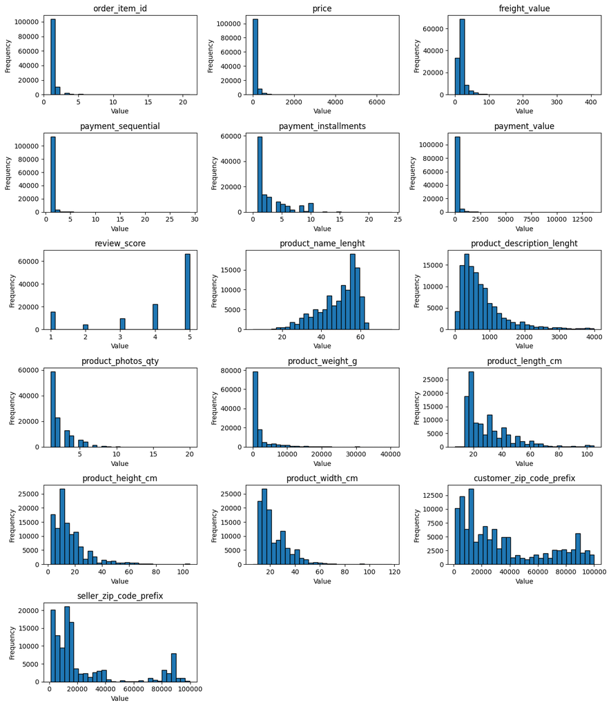

```python
# Memilih hanya kolom numerik
numerical_columns = df_train.select_dtypes(include=['float64','int64']).columns

# Menampilkan histogram untuk setiap variabel numerik
plt.figure(figsize=(13, 15))
for i, col in enumerate(numerical_columns, 1):
    plt.subplot(len(numerical_columns) // 3 + 1, 3, i)
    plt.hist(df_train[col].dropna(), bins=30, edgecolor='black')
    plt.title(col)
    plt.xlabel('Value')
    plt.ylabel('Frequency')
plt.tight_layout()
plt.show()
```

Distribusi sebagian besar variabel menunjukkan skewness ke kanan, dengan banyak nilai berkumpul di sisi kiri grafik, terutama pada harga, berat produk, dan biaya pengiriman. Beberapa variabel seperti review_score dan jumlah foto produk memiliki distribusi diskrit dengan puncak yang jelas di nilai-nilai tertentu.

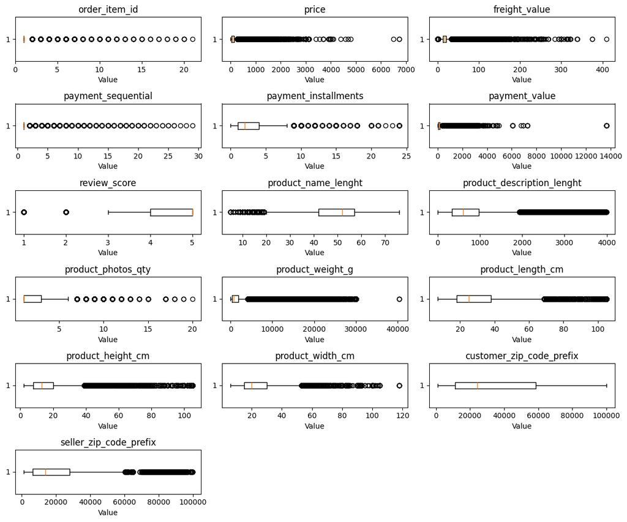

```python
# Memilih hanya kolom numerik
numerical_columns = df_train.select_dtypes(include=['float64','int64']).columns

# Menampilkan boxplot untuk setiap variabel numerik
plt.figure(figsize=(12, 10))
for i, col in enumerate(numerical_columns, 1):
    plt.subplot(len(numerical_columns) // 3 + 1, 3, i)
    plt.boxplot(df_train[col].dropna(), vert=False)
    plt.title(col)
    plt.xlabel('Value')
plt.tight_layout()
plt.show()
```

Boxplot menunjukkan bahwa sebagian besar variabel memiliki outlier yang signifikan, terutama pada harga, nilai pembayaran, dan berat produk, yang menandakan adanya distribusi yang sangat skewed ke kanan.

```python
df_train.dtypes
```

```
order_id                                 object
customer_id                              object
order_status                             object
order_purchase_timestamp         datetime64[ns]
order_approved_at                datetime64[ns]
order_delivered_carrier_date     datetime64[ns]
order_delivered_customer_date    datetime64[ns]
order_estimated_delivery_date    datetime64[ns]
order_item_id                           float64
product_id                               object
seller_id                                object
shipping_limit_date              datetime64[ns]
price                                   float64
freight_value                           float64
payment_sequential                      float64
payment_type                             object
payment_installments                    float64
payment_value                           float64
review_id                                object
review_score                            float64
review_comment_title                     object
review_comment_message                   object
review_creation_date             datetime64[ns]
review_answer_timestamp          datetime64[ns]
product_category_name                    object
product_name_lenght                     float64
product_description_lenght              float64
product_photos_qty                      float64
product_weight_g                        float64
product_length_cm                       float64
product_height_cm                       float64
product_width_cm                        float64
customer_unique_id                       object
customer_zip_code_prefix                  int64
customer_city                            object
customer_state                           object
seller_zip_code_prefix                  float64
seller_city                              object
seller_state                             object
dtype: object
```

```python
# Untuk kolom kategorik, isi dengan modus (nilai yang paling sering muncul)
categorical_columns = df_train.select_dtypes(include=['object']).columns

# Menghitung jumlah nilai unik di setiap kolom kategorik
unique_counts = {col: df_train[col].nunique() for col in categorical_columns}

# Mengurutkan berdasarkan jumlah nilai unik dari terbesar ke terkecil
sorted_unique_counts = dict(sorted(unique_counts.items(), key=lambda item: item[1], reverse=True))

# Menampilkan hasil
for col, count in sorted_unique_counts.items():
    print(f"Number of unique values in {col}: {count}")
```

```
Number of unique values in order_id: 99441
Number of unique values in customer_id: 99441
Number of unique values in review_id: 98410
Number of unique values in customer_unique_id: 96096
Number of unique values in review_comment_message: 36159
Number of unique values in product_id: 32951
Number of unique values in review_comment_title: 4527
Number of unique values in customer_city: 4119
Number of unique values in seller_id: 3095
Number of unique values in seller_city: 611
Number of unique values in product_category_name: 73
Number of unique values in customer_state: 27
Number of unique values in seller_state: 23
Number of unique values in order_status: 8
Number of unique values in payment_type: 5
```

Interpretasi dari jumlah nilai unik ini menunjukkan bahwa order_id dan customer_id memiliki jumlah unik yang sama, yang berarti setiap pesanan berasal dari pelanggan yang berbeda. customer_unique_id lebih sedikit daripada customer_id, menunjukkan bahwa beberapa pelanggan melakukan lebih dari satu pesanan.

Selain itu, jumlah unik pada review_id sedikit lebih kecil dari order_id, mengindikasikan bahwa tidak semua pesanan mendapatkan ulasan. product_id dan seller_id menunjukkan adanya banyak variasi produk dan penjual, sedangkan product_category_name lebih terbatas, menandakan bahwa banyak produk yang masuk dalam kategori yang sama. customer_city dan seller_city cukup beragam, namun jumlah unik seller_city jauh lebih kecil daripada customer_city, yang berarti penjual terkonsentrasi di lokasi tertentu. order_status memiliki 8 kategori, sedangkan payment_type hanya memiliki 5, menunjukkan metode pembayaran yang lebih terbatas dibandingkan status pesanan yang lebih bervariasi.

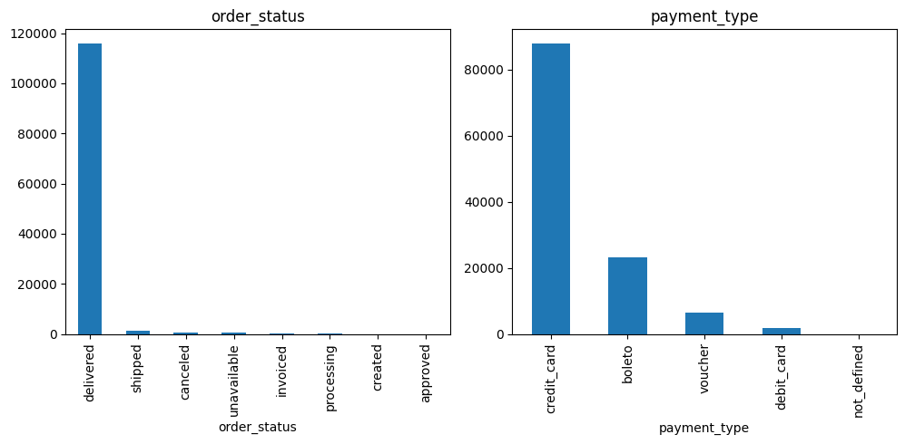

```python
# Untuk kolom kategorik, isi dengan modus (nilai yang paling sering muncul)
categorical_columns = df_train.select_dtypes(include=['object']).columns
# Mengecualikan kolom dengan terlalu banyak kategori
included_columns = ['order_status','payment_type']
categorical_columns = [col for col in categorical_columns if col in included_columns]

# Menampilkan barplot untuk setiap variabel kategorik
plt.figure(figsize=(15, 5))
for i, col in enumerate(categorical_columns, 1):
    plt.subplot(len(categorical_columns) // 3 + 1, 3, i)
    df_train[col].value_counts().plot(kind='bar')
    plt.title(col)
plt.tight_layout()
plt.show()
```

Sebagian besar pesanan berstatus delivered, sedangkan status lainnya seperti shipped, canceled, dan unavailable jauh lebih sedikit, menunjukkan mayoritas transaksi berhasil diselesaikan. Credit_card adalah metode pembayaran paling dominan, diikuti oleh boleto, sementara metode lain seperti voucher dan debit_card digunakan jauh lebih jarang.

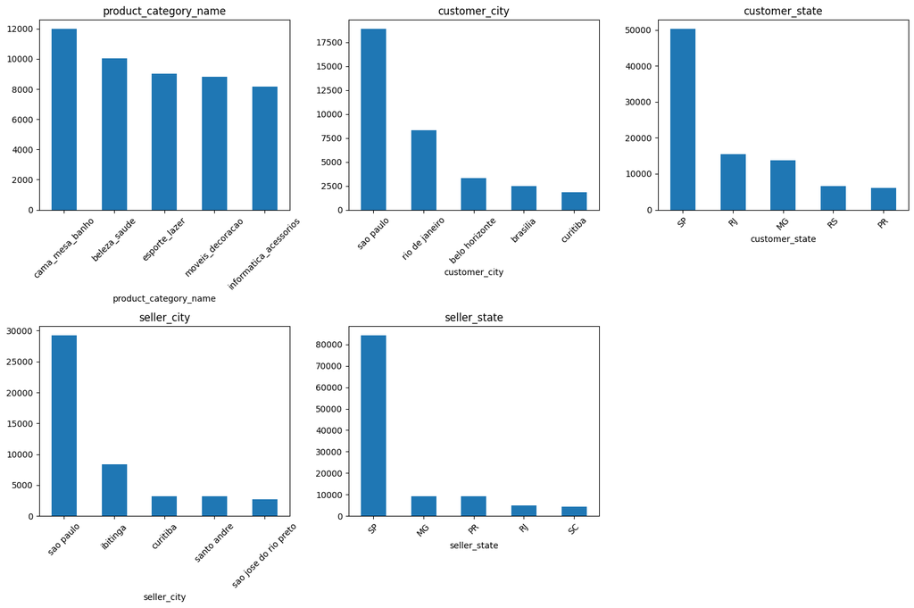

```python
# Untuk kolom kategorik, isi dengan modus (nilai yang paling sering muncul)
categorical_columns = df_train.select_dtypes(include=['object']).columns

# Mengecualikan kolom dengan terlalu banyak kategori
included_columns = ['product_category_name', 'customer_city', 'customer_state', 'seller_city', 'seller_state']
categorical_columns = [col for col in categorical_columns if col in included_columns]

# Menampilkan barplot untuk setiap variabel kategorik (top 5 kategori saja)
plt.figure(figsize=(15, 10))
for i, col in enumerate(categorical_columns, 1):
    plt.subplot(len(categorical_columns) // 3 + 1, 3, i)

    top_5 = df_train[col].value_counts().nlargest(5)  # Ambil 5 kategori terbanyak
    top_5.plot(kind='bar')

    plt.title(col)
    plt.xticks(rotation=45)  # Putar label agar lebih mudah dibaca

plt.tight_layout()
plt.show()
```

Kategori produk cama_mesa_banho paling banyak dipesan, sementara Sao Paulo mendominasi baik sebagai kota dengan jumlah pelanggan maupun penjual terbanyak. Distribusi pelanggan dan penjual menunjukkan konsentrasi tinggi di negara bagian SP, menandakan peran utamanya dalam ekosistem e-commerce.

## Visualization & Explanatory Analysis

### Pertanyaan 1. Bagaimana pengaruh variasi harga produk terhadap jumlah penjualan, terutama untuk produk dengan harga di bawah 1000 satuan mata uang dibandingkan dengan produk yang memiliki harga lebih tinggi?

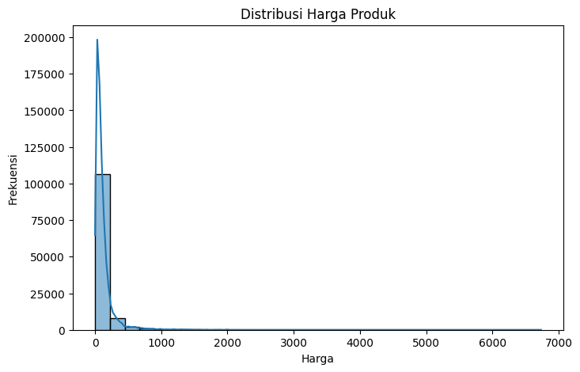

```python
# Plot distribusi harga produk
plt.figure(figsize=(8, 5))
sns.histplot(df_train['price'], bins=30, kde=True)
plt.title('Distribusi Harga Produk')
plt.xlabel('Harga')
plt.ylabel('Frekuensi')
plt.show()
```

Dari gambar di atas, terlihat bahwa harga produk cenderung berada di bawah 1000 satuan mata uang. Namun, terdapat beberapa produk yang memiliki harga jauh di atas 1000 satuan mata uang.

### Pertanyaan 2. Bagaimana preferensi metode pembayaran (misalnya, kartu kredit vs. metode lain) mempengaruhi tingkat konversi dan jumlah transaksi dalam platform e-commerce ini?

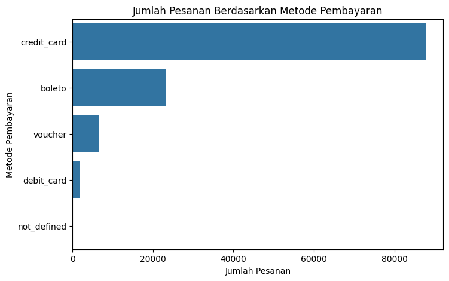

```python
# Plot jumlah pesanan berdasarkan metode pembayaran
plt.figure(figsize=(8, 5))
sns.countplot(y=df_train['payment_type'], order=df_train['payment_type'].value_counts().index)
plt.title('Jumlah Pesanan Berdasarkan Metode Pembayaran')
plt.xlabel('Jumlah Pesanan')
plt.ylabel('Metode Pembayaran')
plt.show()
```

Dari bar chart di atas, dapat dilihat bahwa mayoritas customer membeli produk dengan metode pembayaran menggunakan kartu kredit.

### Pertanyaan 3. Apakah terdapat hubungan antara harga produk, biaya pengiriman, dan skor ulasan pelanggan dalam menentukan kepuasan pelanggan?

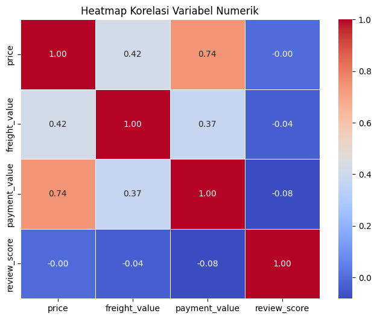

```python
# Pilih kolom numerik yang relevan untuk korelasi
num_cols = ['price', 'freight_value', 'payment_value', 'review_score']

# Hitung korelasi
corr_matrix = df_train[num_cols].corr()

# Plot heatmap
plt.figure(figsize=(8, 6))
sns.heatmap(corr_matrix, annot=True, cmap='coolwarm', fmt='.2f', linewidths=0.5)
plt.title('Heatmap Korelasi Variabel Numerik')
plt.show()
```

Harga produk (price) memiliki korelasi yang cukup kuat dengan nilai pembayaran (payment_value) sebesar 0.74, yang menunjukkan bahwa semakin mahal produk, semakin tinggi jumlah pembayaran yang dilakukan. Skor ulasan (review_score) hampir tidak memiliki korelasi signifikan dengan variabel lain, yang mengindikasikan bahwa faktor harga atau biaya pengiriman tidak secara langsung mempengaruhi penilaian pelanggan.

### Pertanyaan 4. Bagaimana distribusi biaya pengiriman untuk produk dengan harga rendah dibandingkan dengan produk yang lebih mahal, dan apakah terdapat tren tertentu dalam hubungan antara keduanya?

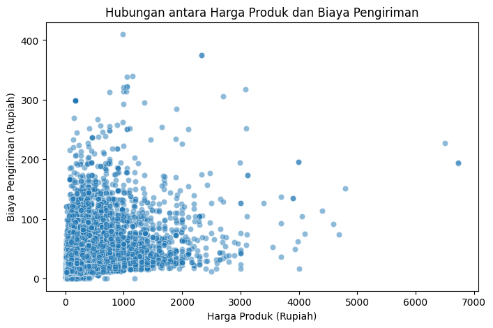

```python
plt.figure(figsize=(8, 5))
sns.scatterplot(x=df_train['price'], y=df_train['freight_value'], alpha=0.5)
plt.title('Hubungan antara Harga Produk dan Biaya Pengiriman')
plt.xlabel('Harga Produk (Rupiah)')
plt.ylabel('Biaya Pengiriman (Rupiah)')
plt.show()
```

Sebagian besar produk dengan harga rendah (di bawah 1000 Rupiah) memiliki biaya pengiriman yang bervariasi. Tidak terlihat hubungan linier yang kuat antara harga produk dan biaya pengiriman, yang mengindikasikan bahwa biaya pengiriman tidak selalu meningkat seiring dengan harga produk.

### Pertanyaan 5. Bagaimana metode pembayaran mempengaruhi kepuasan pelanggan, dan apakah terdapat pola tertentu yang menunjukkan hubungan antara metode pembayaran dan skor ulasan?

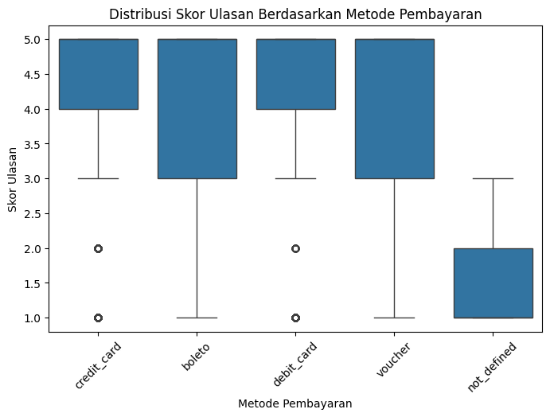

```python
plt.figure(figsize=(8, 5))
sns.boxplot(x=df_train['payment_type'], y=df_train['review_score'])
plt.title('Distribusi Skor Ulasan Berdasarkan Metode Pembayaran')
plt.xlabel('Metode Pembayaran')
plt.ylabel('Skor Ulasan')
plt.xticks(rotation=45)
plt.show()
```

Mayoritas metode pembayaran seperti credit_card, boleto, debit_card, dan voucher memiliki distribusi skor ulasan yang tinggi, tetapi tetap ada beberapa ulasan rendah (outlier di skor 1 dan 2). Metode pembayaran "not_defined" memiliki distribusi skor ulasan yang lebih rendah dibandingkan metode lainnya, dengan banyak skor berada di kisaran 1 hingga 2, yang menunjukkan kemungkinan adanya masalah pada transaksi atau pengalaman pelanggan yang kurang baik.

### Pertanyaan 6. Kategori produk apa yang memiliki jumlah pesanan tertinggi, dan bagaimana perbandingan jumlah pesanan di antara 10 kategori produk teratas?

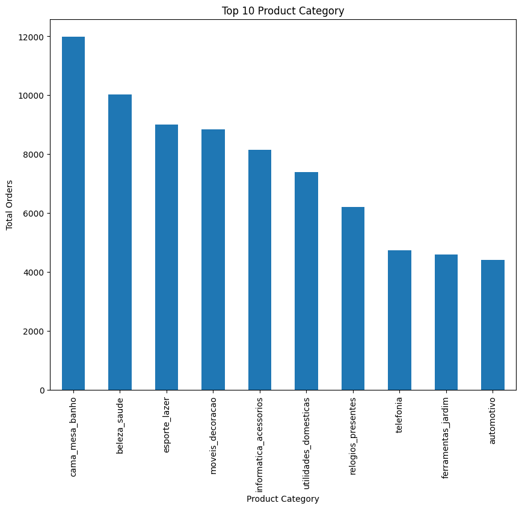

```python
# Bar Plot untuk melihat kategori produk yang paling banyak dibeli
plt.figure(figsize=(10, 8))
df_train['product_category_name'].value_counts().head(10).plot(kind='bar')
plt.title('Top 10 Product Category')
plt.xlabel('Product Category')
plt.ylabel('Total Orders')
plt.show()
```

- Kategori "cama_mesa_banho" memiliki jumlah pesanan tertinggi, sekitar 12.000 pesanan, yang menunjukkan bahwa kategori ini sangat populer di antara konsumen.
- Kategori "beleza_saude" berada di peringkat kedua, diikuti oleh "esporte_lazer". Keduanya memiliki jumlah pesanan yang cukup tinggi, tetapi lebih rendah dibandingkan "cama_mesa_banho".
- Kategori seperti "moveis_decoracao", "informatica_acessorios", dan "utilidades_domesticas" memiliki jumlah pesanan dalam rentang yang sama, yaitu 7000-9000. "Relogios_presentes" menempati posisi selanjutnya lebih rendah dari kategori sebelumnya.
- Kategori "telefonia", "ferramentas_jardim", dan "automotivo" memiliki jumlah pesanan yang lebih rendah dibandingkan kategori lainnya, tetapi tetap masuk dalam 10 besar.

### Pertanyaan 7. Pada jam berapa aktivitas pemesanan paling tinggi dan paling rendah dalam sehari, serta bagaimana tren pesanan berubah sepanjang hari?

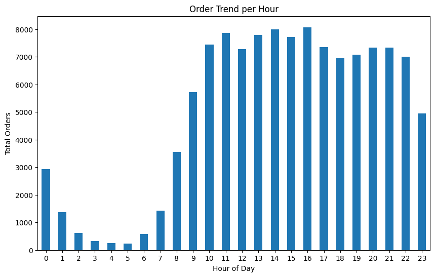

```python
# Group data berdasarkan jam
df_train['hour'] = df_train['order_purchase_timestamp'].dt.hour
hourly_orders = df_train['hour'].value_counts().sort_index()

# Plot untuk melihat tren jumlah pesanan berdasarkan jam
hourly_orders.plot(kind='bar', figsize=(10, 6))
plt.title('Order Trend per Hour')
plt.xlabel('Hour of Day')
plt.ylabel('Total Orders')
plt.xticks(rotation=0)  # Pastikan label sumbu X tetap horizontal
plt.show()
```

- Terlihat bahwa waktu paling sibuk untuk pesanan adalah antara jam 10 pagi hingga jam 10 malam. Sedangkan, waktu paling sepi adalah jam 2 pagi hingga jam 6 pagi.

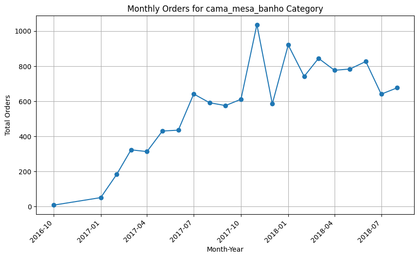

```python
# Analisis tren kategori cama_mesa_banho berdasarkan waktu bulanan
df_train['month_year'] = df_train['order_purchase_timestamp'].dt.to_period('M')
df_train['month_year'] = df_train['month_year'].dt.to_timestamp()

# Filter data hanya untuk kategori cama_mesa_banho
df_cama_mesa_banho = df_train[df_train['product_category_name'] == 'cama_mesa_banho']

# Group data berdasarkan bulan dan tahun
monthly_orders = df_cama_mesa_banho.groupby('month_year').size()

# Plot untuk melihat tren jumlah pesanan kategori cama_mesa_banho berdasarkan bulan
monthly_orders.plot(kind='line', figsize=(10, 6), marker='o')
plt.title('Monthly Orders for cama_mesa_banho Category')
plt.xlabel('Month-Year')
plt.ylabel('Total Orders')
plt.xticks(rotation=45)  # Pastikan label sumbu X tetap horizontal
plt.grid(True)
plt.show()
```

Apabila kita ambil sampel kategori "cama_mesa_banho" sebagai contoh, kita dapat melihat tren pembelian produk ini sepanjang tahun. Dari grafik, kita dapat melihat bahwa jumlah pesanan cenderung meningkat pada bulan-bulan dan pada tahun tertentu. Hal ini menunjukkan bahwa ada tren musiman dalam pembelian kategori produk ini. Mungkin ada faktor-faktor tertentu yang mempengaruhi tren ini, seperti promosi, penawaran khusus, atau peristiwa tertentu yang terjadi pada bulan-bulan tersebut, seperti musim dingin dan sebagainya.

### Pertanyaan 8. Berapa proporsi pesanan yang dikirim tepat waktu dibandingkan dengan pesanan yang terlambat, dan sejauh mana keterlambatan pengiriman menjadi masalah bagi pelanggan?

```python
# Menambahkan kolom "telat_diantar" ke dataset `df_train`, jika dataset `df_train` sudah menggabungkan kolom yang relevan.

# Convert dates to datetime for accurate comparison
df_train['order_delivered_customer_date'] = pd.to_datetime(df_train['order_delivered_customer_date'], errors='coerce')
df_train['order_estimated_delivery_date'] = pd.to_datetime(df_train['order_estimated_delivery_date'], errors='coerce')

# Add a new column for late delivery
df_train['telat_diantar'] = df_train['order_delivered_customer_date'] > df_train['order_estimated_delivery_date']

# Check the updated dataset
df_train[['order_id', 'order_delivered_customer_date', 'order_estimated_delivery_date', 'telat_diantar']]
```

|  | order_id | order_delivered_customer_date | order_estimated_delivery_date | telat_diantar |
| --- | --- | --- | --- | --- |
| 0 | d455a8cb295653b55abda06d434ab492 | 2017-10-07 16:12:47 | 2017-10-30 | False |
| 1 | 7f39ba4c9052be115350065d07583cac | 2017-10-27 16:46:05 | 2017-11-09 | False |
| 2 | 9dc8d1a6f16f1b89874c29c9d8d30447 | 2017-10-24 20:17:44 | 2017-11-06 | False |
| 3 | 0f548bd29148ebc519d6495e37a284e1 | 2017-09-08 16:26:55 | 2017-09-27 | False |
| 4 | 0f548bd29148ebc519d6495e37a284e1 | 2017-09-08 16:26:55 | 2017-09-27 | False |
| ... | ... | ... | ... | ... |
| 119138 | 87ae60ef8b08ae0e5f903cacb53a6904 | NaT | 2018-09-26 | False |
| 119139 | d69fcef5a5fe3a3db60ea65c6ee499cc | NaT | 2018-01-08 | False |
| 119140 | f86d7bc39aab05299691322044b63bb2 | NaT | 2018-09-25 | False |
| 119141 | 74f833bf7c70ce8c3f820f725c213e1c | NaT | 2017-08-01 | False |
| 119142 | 2e935fa1d39497aa0ec3f1107fbfb5b8 | NaT | 2017-10-24 | False |

119143 rows × 4 columns

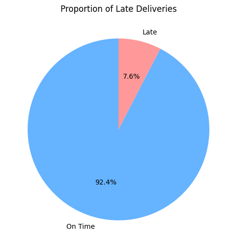

```python
# Visualisasi data Pie Chart untuk melihat proporsi data yang terlambat diantar
# Calculate the proportion of late deliveries
late_deliveries = df_train['telat_diantar'].value_counts(normalize=True) * 100

# Create a pie chart
plt.figure(figsize=(8, 6))
plt.pie(late_deliveries, labels=['On Time', 'Late'], autopct='%1.1f%%', startangle=90, colors=['#66b3ff','#ff9999'])
plt.title('Proportion of Late Deliveries')
plt.show()
```

- Sebanyak 7.6% pesanan masih terlambat diantar. Hal ini perlu diperhatikan oleh perusahaan untuk meningkatkan efisiensi pengiriman.

## Analisis Lanjutan

### Pertanyaan 9. Siapa saja pelanggan terbaik berdasarkan parameter RFM (Recency, Frequency, Monetary), dan bagaimana strategi yang dapat diterapkan untuk meningkatkan retensi serta nilai pelanggan?

#### RFM Analysis

Tujuan: Mengidentifikasi pelanggan terbaik berdasarkan parameter RFM untuk merancang strategi retensi dan peningkatan nilai pelanggan.

```python
df_train.columns
```

```
Index(['order_id', 'customer_id', 'order_status', 'order_purchase_timestamp',
       'order_approved_at', 'order_delivered_carrier_date',
       'order_delivered_customer_date', 'order_estimated_delivery_date',
       'order_item_id', 'product_id', 'seller_id', 'shipping_limit_date',
       'price', 'freight_value', 'payment_sequential', 'payment_type',
       'payment_installments', 'payment_value', 'review_id', 'review_score',
       'review_comment_title', 'review_comment_message',
       'review_creation_date', 'review_answer_timestamp',
       'product_category_name', 'product_name_lenght',
       'product_description_lenght', 'product_photos_qty', 'product_weight_g',
       'product_length_cm', 'product_height_cm', 'product_width_cm',
       'customer_unique_id', 'customer_zip_code_prefix', 'customer_city',
       'customer_state', 'seller_zip_code_prefix', 'seller_city',
       'seller_state', 'hour', 'month_year', 'telat_diantar'],
      dtype='object')
```

```python
df_train.groupby("customer_unique_id")["order_id"].nunique().sort_values(ascending=False).head(10)
```

```
customer_unique_id
8d50f5eadf50201ccdcedfb9e2ac8455    17
3e43e6105506432c953e165fb2acf44c     9
6469f99c1f9dfae7733b25662e7f1782     7
ca77025e7201e3b30c44b472ff346268     7
1b6c7548a2a1f9037c1fd3ddfed95f33     7
12f5d6e1cbf93dafd9dcc19095df0b3d     6
de34b16117594161a6a89c50b289d35a     6
63cfc61cee11cbe306bff5857d00bfe4     6
f0e310a6839dce9de1638e0fe5ab282a     6
47c1a3033b8b77b3ab6e109eb4d5fdf3     6
Name: order_id, dtype: int64
```

```python
rfm_df = df_train.groupby(by="customer_unique_id", as_index=False).agg({
    "order_purchase_timestamp": "max", # mengambil tanggal order terakhir
    "order_id": "nunique", # menghitung jumlah order
    "price": "sum" # menghitung jumlah revenue yang dihasilkan
})

rfm_df.columns = ["customer_unique_id", "max_order_purchase_timestamp", "frequency", "monetary"]

# menghitung pada hari apa terakhir terakhir pelanggan melakukan transaksi
rfm_df["max_order_purchase_timestamp"] = rfm_df["max_order_purchase_timestamp"].dt.date
recent_date = df_train["order_purchase_timestamp"].dt.date.max()
rfm_df["recency"] = rfm_df["max_order_purchase_timestamp"].apply(lambda x: (recent_date - x).days)
rfm_df.drop(columns="max_order_purchase_timestamp", axis=1, inplace=True)
rfm_df.sort_values("frequency", ascending=False).head(10)
```

|  | customer_unique_id | frequency | monetary | recency |
| --- | --- | --- | --- | --- |
| 52973 | 8d50f5eadf50201ccdcedfb9e2ac8455 | 17 | 729.62 | 58 |
| 23472 | 3e43e6105506432c953e165fb2acf44c | 9 | 1000.85 | 232 |
| 37797 | 6469f99c1f9dfae7733b25662e7f1782 | 7 | 664.20 | 111 |
| 76082 | ca77025e7201e3b30c44b472ff346268 | 7 | 806.61 | 138 |
| 10354 | 1b6c7548a2a1f9037c1fd3ddfed95f33 | 7 | 855.21 | 245 |
| 7175 | 12f5d6e1cbf93dafd9dcc19095df0b3d | 6 | 58.40 | 650 |
| 83540 | de34b16117594161a6a89c50b289d35a | 6 | 486.00 | 273 |
| 37585 | 63cfc61cee11cbe306bff5857d00bfe4 | 6 | 579.81 | 142 |
| 90451 | f0e310a6839dce9de1638e0fe5ab282a | 6 | 438.09 | 195 |
| 27043 | 47c1a3033b8b77b3ab6e109eb4d5fdf3 | 6 | 874.60 | 266 |

[output not shown]

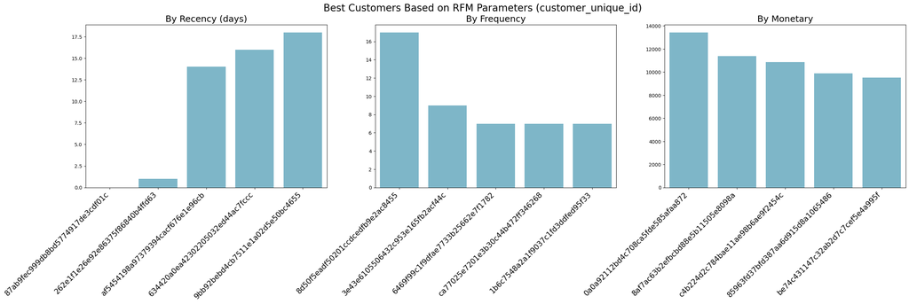

```python
fig, ax = plt.subplots(nrows=1, ncols=3, figsize=(30,6))

colors = ["#72BCD4", "#72BCD4", "#72BCD4", "#72BCD4", "#72BCD4"]

sns.barplot(y="recency", x="customer_unique_id", data=rfm_df.sort_values("recency", ascending=True).head(5), palette=colors, ax=ax[0])
ax[0].set_ylabel(None)
ax[0].set_xlabel(None)
ax[0].set_title("By Recency (days)", loc="center", fontsize=18)
ax[0].tick_params(axis='x', labelsize=15, rotation =45)
ax[0].set_xticklabels(ax[0].get_xticklabels(), ha="right")  # Geser ke kiri

sns.barplot(y="frequency", x="customer_unique_id", data=rfm_df.sort_values("frequency", ascending=False).head(5), palette=colors, ax=ax[1])
ax[1].set_ylabel(None)
ax[1].set_xlabel(None)
ax[1].set_title("By Frequency", loc="center", fontsize=18)
ax[1].tick_params(axis='x', labelsize=15, rotation =45)
ax[1].set_xticklabels(ax[1].get_xticklabels(), ha="right")  # Geser ke kiri

sns.barplot(y="monetary", x="customer_unique_id", data=rfm_df.sort_values("monetary", ascending=False).head(5), palette=colors, ax=ax[2])
ax[2].set_ylabel(None)
ax[2].set_xlabel(None)
ax[2].set_title("By Monetary", loc="center", fontsize=18)
ax[2].tick_params(axis='x', labelsize=15, rotation =45)
ax[2].set_xticklabels(ax[2].get_xticklabels(), ha="right")  # Geser ke kiri

plt.suptitle("Best Customers Based on RFM Parameters (customer_unique_id)", fontsize=20)
plt.show()
```

Berdasarkan visualisasi data di atas, dapat dilihat beberapa pelanggan terbaik berdasarkan ketiga parameter RFM. Pembeli terbanyak mungkin saja diberi imbalan berupa penawaran eksklusif, sedangkan pelanggan dengan frekuensi pembelian terbaru tetapi rendah mungkin memerlukan iklan atau sebagainya.

## Conclusion

1. **Pengaruh Variasi Harga Produk terhadap Jumlah Penjualan**  
   Hasil analisis menunjukkan bahwa sebagian besar produk yang terjual memiliki harga di bawah 1000 satuan mata uang. Produk dengan harga lebih tinggi memiliki jumlah penjualan yang lebih rendah, mengindikasikan bahwa harga merupakan faktor penting dalam keputusan pembelian pelanggan.
2. **Preferensi Metode Pembayaran dan Dampaknya terhadap Konversi**  
   Mayoritas pelanggan lebih memilih menggunakan kartu kredit sebagai metode pembayaran utama, dengan metode lain seperti boleto, debit card, dan voucher memiliki penggunaan yang jauh lebih rendah. Hal ini menunjukkan bahwa kartu kredit mungkin menawarkan kenyamanan atau keuntungan tambahan bagi pelanggan.
3. **Hubungan antara Harga Produk, Biaya Pengiriman, dan Skor Ulasan**  
   Analisis korelasi menunjukkan bahwa harga produk dan biaya pengiriman tidak memiliki hubungan yang signifikan dengan skor ulasan pelanggan. Ini mengindikasikan bahwa faktor lain, seperti kualitas produk atau layanan pelanggan, mungkin lebih berperan dalam menentukan kepuasan pelanggan.
4. **Distribusi Biaya Pengiriman Berdasarkan Harga Produk**  
   Produk dengan harga rendah memiliki variasi biaya pengiriman yang cukup besar, sementara produk yang lebih mahal tidak selalu dikenakan biaya pengiriman yang lebih tinggi. Ini menunjukkan bahwa biaya pengiriman tidak selalu sebanding dengan harga produk dan bisa dipengaruhi oleh faktor lain seperti jarak atau kebijakan vendor.
5. **Hubungan antara Metode Pembayaran dan Skor Ulasan**  
   Sebagian besar metode pembayaran memiliki distribusi skor ulasan yang tinggi, tetapi metode "not_defined" cenderung memiliki skor ulasan yang lebih rendah. Hal ini bisa mengindikasikan adanya kendala atau masalah transaksi pada metode pembayaran yang tidak terdefinisi dengan baik.
6. **Kategori Produk dengan Jumlah Pesanan Tertinggi**  
   Kategori **"cama_mesa_banho"** memiliki jumlah pesanan tertinggi, diikuti oleh **"beleza_saude"** dan **"esporte_lazer"**. Ini menunjukkan bahwa produk rumah tangga dan kesehatan kecantikan memiliki daya tarik yang tinggi bagi pelanggan.
7. **Tren Pemesanan Berdasarkan Jam**  
   Pesanan tertinggi terjadi antara pukul **10 pagi hingga 10 malam**, sedangkan pemesanan paling rendah terjadi antara **2 pagi hingga 6 pagi**. Hal ini mengindikasikan bahwa sebagian besar pelanggan melakukan pembelian saat jam kerja atau waktu senggang di malam hari.
8. **Proporsi Pengiriman Tepat Waktu vs. Terlambat**  
   Sebanyak **92.4% pesanan dikirim tepat waktu**, sementara **7.6% pesanan mengalami keterlambatan**. Meskipun sebagian besar pengiriman berjalan lancar, perlu dilakukan optimasi pada pesanan yang masih mengalami keterlambatan untuk meningkatkan kepuasan pelanggan.
9. **Identifikasi Pelanggan Terbaik Berdasarkan RFM**  
   Beberapa pelanggan memiliki skor terbaik berdasarkan **Recency, Frequency, dan Monetary (RFM)**. Pelanggan dengan nilai pembelian tinggi dapat diberi imbalan dengan penawaran eksklusif, sementara pelanggan dengan frekuensi pembelian rendah dapat ditargetkan dengan strategi pemasaran ulang untuk meningkatkan retensi mereka.